# Waiter’s Tip Prediction in R

Mrinal Kanti Saha (21234) and Parth Maheshwari (21235)

May 5, 2022

# 1 Loading all the required libraries

```r
library(tidyverse)
library(naniar)
library(GGally)
library(caret)
library(car)
library(dplyr)
library(reshape)
library(leaps)
library(MASS)
library(corrplot)
library(ggalt)
```

# 2 Loading the dataset

```r
# set working directory
setwd("/home/msc1/R_Project/Dataset_Tips")
# check the directory
getwd()
```

```
## [1] "/home/msc1/R_Project/Dataset_Tips"
```

```r
# import the dataset and read the strings as factors
tips <- read.csv("./tips.csv", stringsAsFactors = TRUE)
```

# 3 Exploratory Data Analysis

```r
# Dimension of the data, no of rows and columns
dim(tips)
```

```
## [1] 244   7
```

```r
# First 6 rows
head(tips)
```

```
##   total_bill  tip    sex smoker day   time size
## 1      16.99 1.01 Female     No Sun Dinner    2
## 2      10.34 1.66   Male     No Sun Dinner    3
## 3      21.01 3.50   Male     No Sun Dinner    3
## 4      23.68 3.31   Male     No Sun Dinner    2
## 5      24.59 3.61 Female     No Sun Dinner    4
## 6      25.29 4.71   Male     No Sun Dinner    4
```

```r
# Names of the columns
names(tips)
```

```
## [1] "total_bill" "tip"        "sex"        "smoker"     "day"
## [6] "time"       "size"
```

```r
# Structure of the dataframe tips
str(tips)
```

```
## 'data.frame':    244 obs. of  7 variables:
##  $ total_bill: num  17 10.3 21 23.7 24.6 ...
##  $ tip       : num  1.01 1.66 3.5 3.31 3.61 4.71 2 3.12 1.96 3.23 ...
##  $ sex       : Factor w/ 2 levels "Female","Male": 1 2 2 2 1 2 2 2 2 2 ...
##  $ smoker    : Factor w/ 2 levels "No","Yes": 1 1 1 1 1 1 1 1 1 1 ...
##  $ day       : Factor w/ 4 levels "Fri","Sat","Sun",..: 3 3 3 3 3 3 3 3 3 3 ...
##  $ time      : Factor w/ 2 levels "Dinner","Lunch": 1 1 1 1 1 1 1 1 1 1 ...
##  $ size      : int  2 3 3 2 4 4 2 4 2 2 ...
```

```r
# 6 point info about each feature
summary(tips)
```

```
##    total_bill         tip             sex      smoker      day         time
##  Min.   : 3.07   Min.   : 1.000   Female: 87   No :151   Fri :19   Dinner:176
##  1st Qu.:13.35   1st Qu.: 2.000   Male  :157   Yes: 93   Sat :87   Lunch : 68
##  Median :17.80   Median : 2.900                          Sun :76
##  Mean   :19.79   Mean   : 2.998                          Thur:62
##  3rd Qu.:24.13   3rd Qu.: 3.562
##  Max.   :50.81   Max.   :10.000
##       size
##  Min.   :1.00
##  1st Qu.:2.00
##  Median :2.00
##  Mean   :2.57
##  3rd Qu.:3.00
##  Max.   :6.00
```

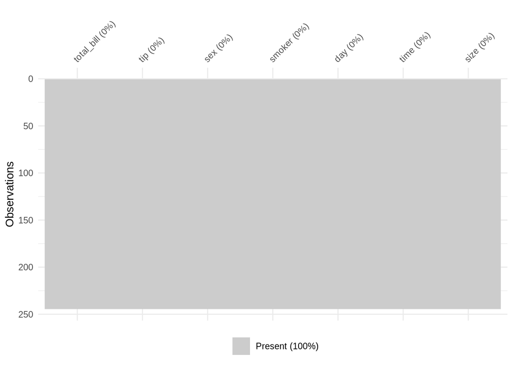

```r
# Do we have missing values ?
# Plot of missing values
vis_miss(tips)
```

All the data values are present.

```r
# Data frame of numerical features
num_cols <- unlist(lapply(tips, is.numeric))
tips_num <- tips[, num_cols]
head(tips_num)
```

```
##   total_bill  tip size
## 1      16.99 1.01    2
## 2      10.34 1.66    3
## 3      21.01 3.50    3
## 4      23.68 3.31    2
## 5      24.59 3.61    4
## 6      25.29 4.71    4
```

# 4 Data Visualization

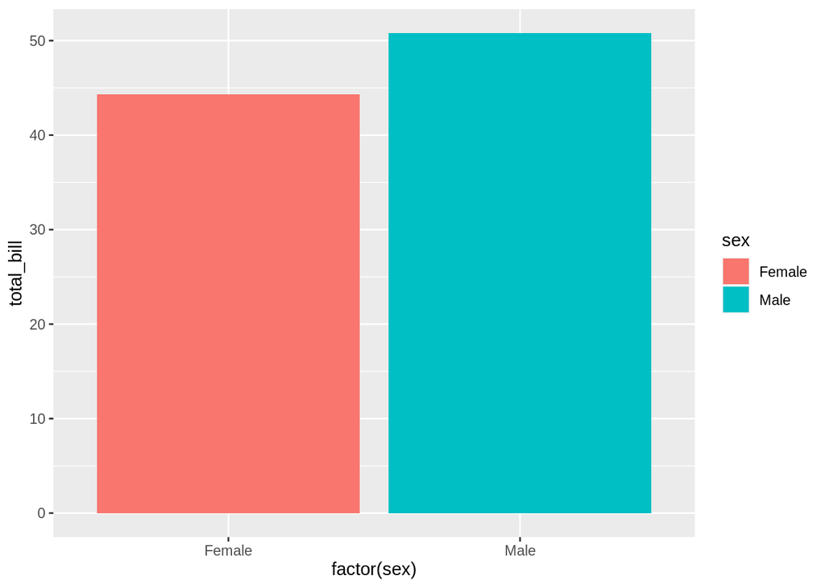

```r
ggplot(as.data.frame(tips), aes(factor(sex), total_bill, fill = sex)) +
  geom_col(position = 'dodge')
```

Inference: There isn’t much difference when it comes to pay for total_bill. Males leading the table

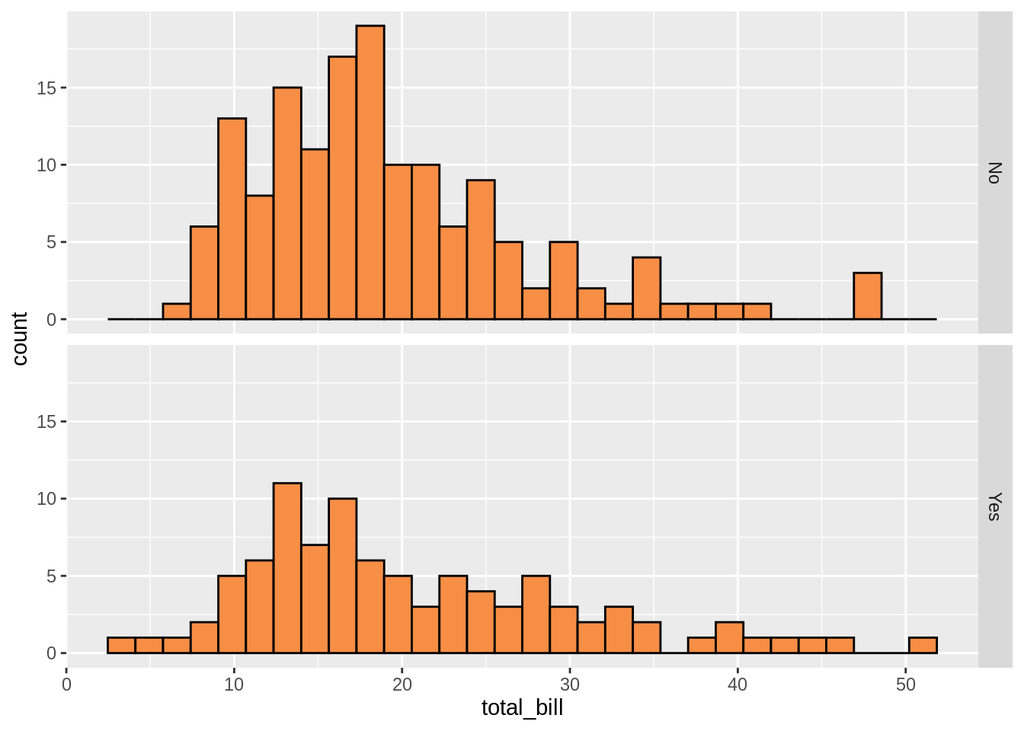

```r
ggplot(tips, aes(x = total_bill)) +
  geom_histogram(fill = "#F78e46", colour = "black") +
  facet_grid(smoker ~ .)
```

Inference: Non-smoker are higher than smoker in range of 10-30 range of total_bill

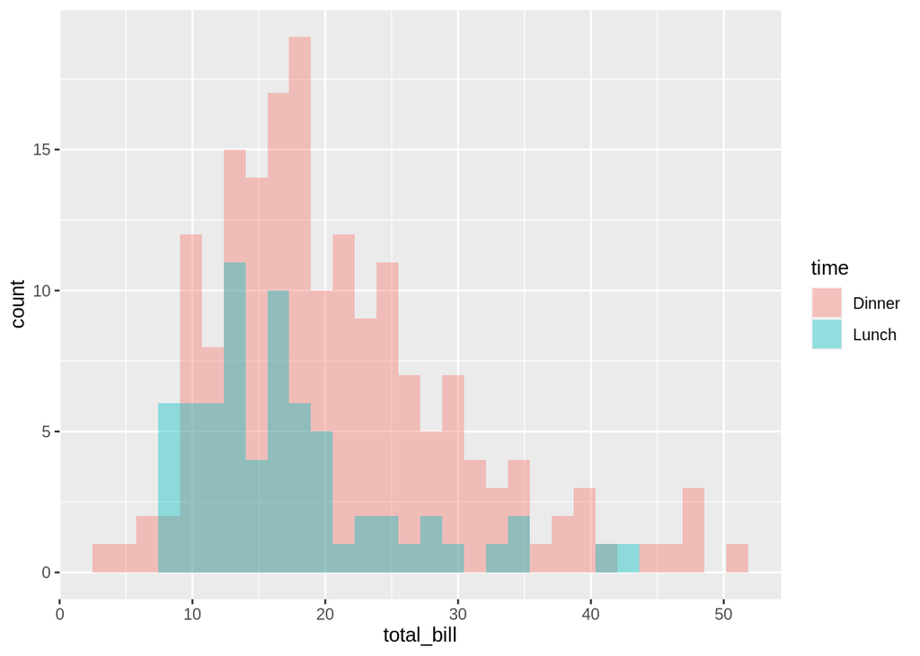

```r
ggplot(tips, aes(x = total_bill, fill = time)) +
  geom_histogram(position = "identity", alpha = 0.4)
```

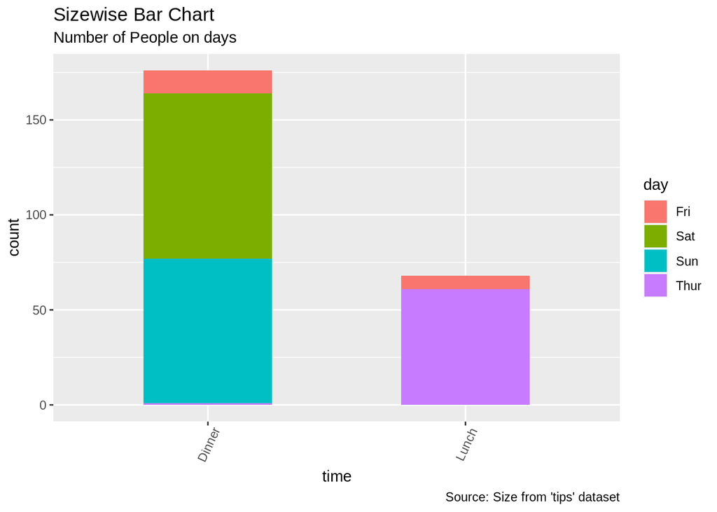

```r
g <- ggplot(tips, aes(time))
g + geom_bar(aes(fill=day), width = 0.5) +
  theme(axis.text.x = element_text(angle=65, vjust=0.6)) +
  labs(title="Sizewise Bar Chart",
       subtitle="Number of People on days",
       caption="Source: Size from 'tips' dataset")
```

Inference: People prefer dinner over lunch in large number

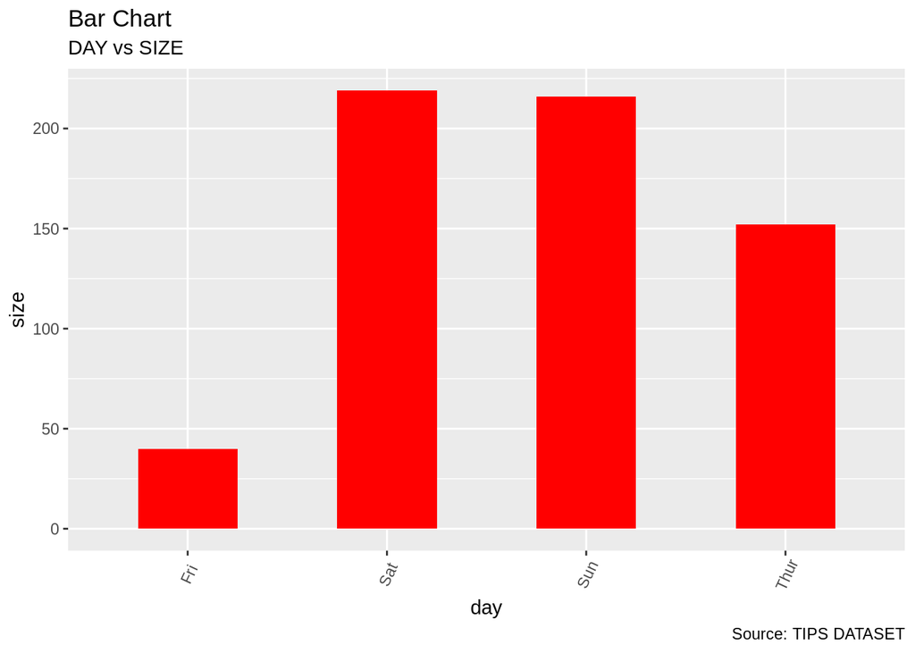

```r
g <- ggplot(tips, aes(day, size))
g + geom_bar(stat="identity", width = 0.5, fill="red") +
  labs(title="Bar Chart",
       subtitle="DAY vs SIZE",
       caption="Source: TIPS DATASET") +
  theme(axis.text.x = element_text(angle=65, vjust=0.6))
```

Inference: The size of the party is much higher on the weekends

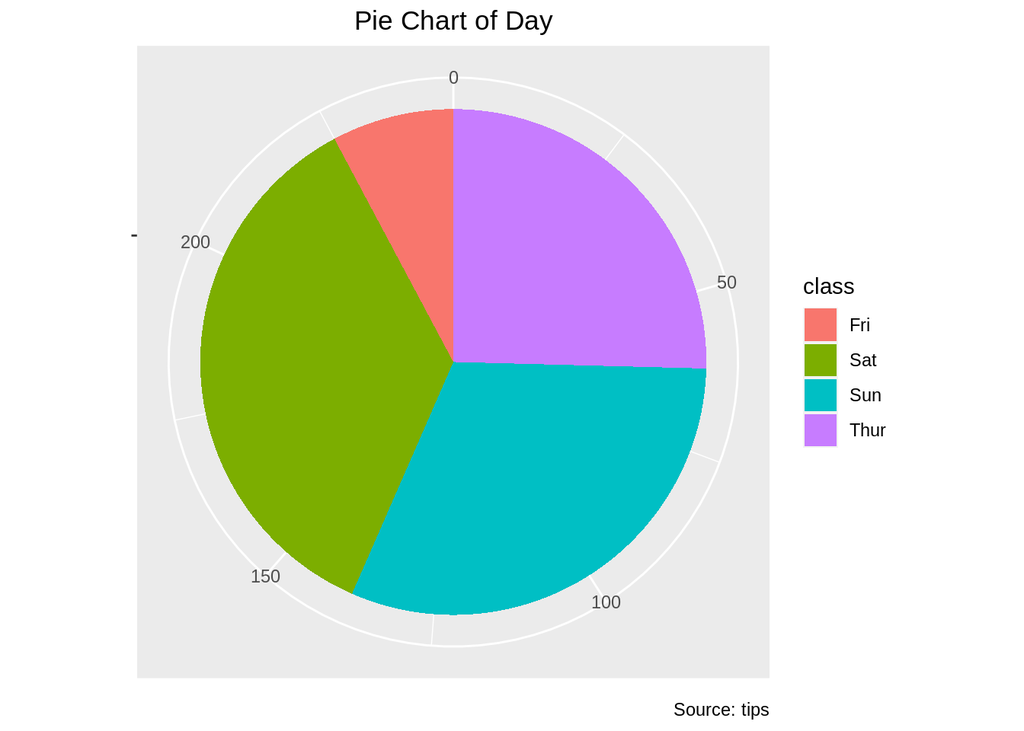

```r
pie <- ggplot(tips, aes(x = "", fill = factor(day))) +
  geom_bar(width = 1) +
  theme(axis.line = element_blank(),
        plot.title = element_text(hjust=0.5)) +
  labs(fill="class",
       x=NULL,
       y=NULL,
       title="Pie Chart of Day",
       caption="Source: tips")

pie + coord_polar(theta = "y", start=0)
```

Inference: People are most likely to have food on saturday and sunday

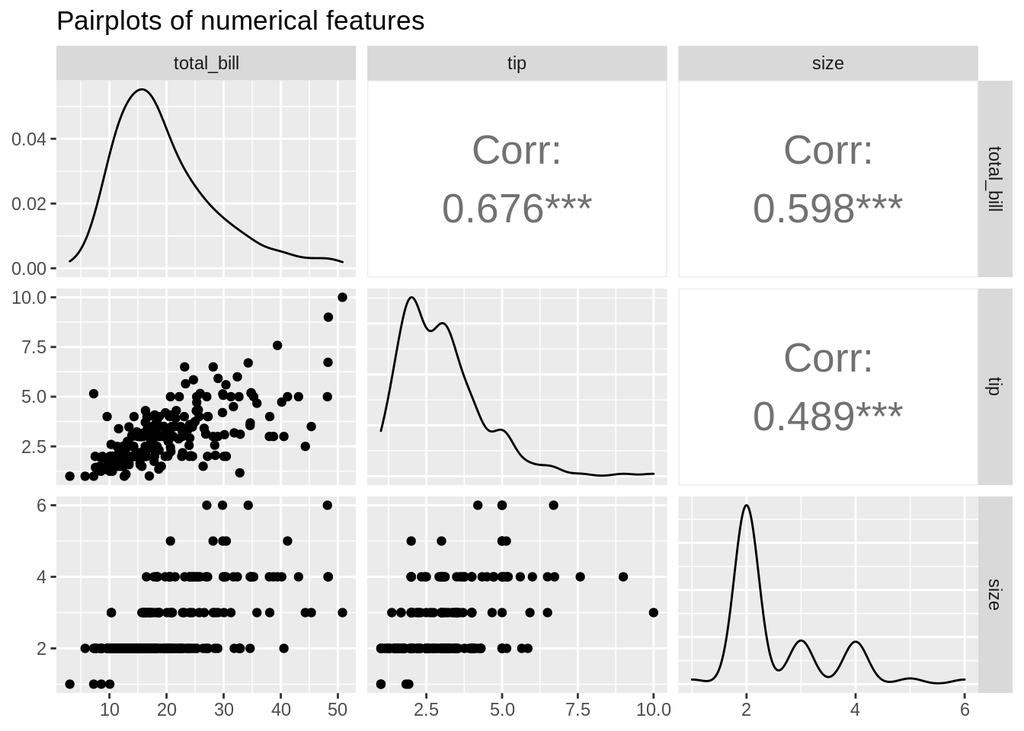

```r
# Pairplot
ggpairs(data = tips_num, title = "Pairplots of numerical features",
        upper = list(continuous = wrap("cor", size = 7)))
```

Inference: The data seems linear between tip and total_bill

# 5 Feature Engineering

```r
tips %>%
  group_by(day) %>%
  summarise_at(vars(tip), list(name = mean))
```

```
## # A tibble: 4 × 2
##   day    name
##   <fct> <dbl>
## 1 Fri    2.73
## 2 Sat    2.99
## 3 Sun    3.26
## 4 Thur   2.77
```

```r
# 1 Fri    2.73 1
# 2 Sat    2.99 3
# 3 Sun    3.26 4
# 4 Thur   2.77 2
# From this, we are trying to derive an ordering for the day variable.
tips$day <- as.factor(ifelse(tips$day=="Thur", 2,
                      ifelse(tips$day=="Fri", 1,
                      ifelse(tips$day=="Sat", 3,
                      ifelse(tips$day=="Sun", 4, 5)))))

# Convert categorical features using One Hot Encoding
# dummy <- dummyVars(" ~ .", data = tips)
# new_tips <- data.frame(predict(dummy, newdata = tips))
# head(new_tips)
# head(tips)

# Convert categorical features using Ordinal Encoding
new_tips <- data.frame(tips)
new_tips$day <- unclass(tips$day)
new_tips$time <- unclass(tips$time)
new_tips$sex <- unclass(tips$sex)
new_tips$smoker <- unclass(tips$smoker)
head(new_tips)
```

```
##   total_bill  tip sex smoker day time size
## 1      16.99 1.01   1      1   4    1    2
## 2      10.34 1.66   2      1   4    1    3
## 3      21.01 3.50   2      1   4    1    3
## 4      23.68 3.31   2      1   4    1    2
## 5      24.59 3.61   1      1   4    1    4
## 6      25.29 4.71   2      1   4    1    4
```

```r
str(new_tips)
```

```
## 'data.frame':    244 obs. of  7 variables:
##  $ total_bill: num  17 10.3 21 23.7 24.6 ...
##  $ tip       : num  1.01 1.66 3.5 3.31 3.61 4.71 2 3.12 1.96 3.23 ...
##  $ sex       : int  1 2 2 2 1 2 2 2 2 2 ...
##   ..- attr(*, "levels")= chr [1:2] "Female" "Male"
##  $ smoker    : int  1 1 1 1 1 1 1 1 1 1 ...
##   ..- attr(*, "levels")= chr [1:2] "No" "Yes"
##  $ day       : int  4 4 4 4 4 4 4 4 4 4 ...
##   ..- attr(*, "levels")= chr [1:4] "1" "2" "3" "4"
##  $ time      : int  1 1 1 1 1 1 1 1 1 1 ...
##   ..- attr(*, "levels")= chr [1:2] "Dinner" "Lunch"
##  $ size      : int  2 3 3 2 4 4 2 4 2 2 ...
```

# 6 Building a Generalised Model

```r
model <- lm(tip ~ ., data = new_tips)
summary(model)
```

```
##
## Call:
## lm(formula = tip ~ ., data = new_tips)
##
## Residuals:
##     Min      1Q  Median      3Q     Max
## -2.8918 -0.5753 -0.0608  0.4999  4.0673
##
## Coefficients:
##              Estimate Std. Error t value Pr(>|t|)
## (Intercept)  0.805882   0.641380   1.256   0.2102
## total_bill   0.094076   0.009524   9.877   <2e-16 ***
## sex         -0.029216   0.141060  -0.207   0.8361
## smoker      -0.081041   0.143742  -0.564   0.5734
## day          0.007834   0.100381   0.078   0.9379
## time         0.005721   0.203697   0.028   0.9776
## size         0.179367   0.089111   2.013   0.0453 *
## ---
## Signif. codes:  0 '***' 0.001 '**' 0.01 '*' 0.05 '.' 0.1 ' ' 1
##
## Residual standard error: 1.021 on 237 degrees of freedom
## Multiple R-squared:  0.4688, Adjusted R-squared:  0.4553
## F-statistic: 34.86 on 6 and 237 DF,  p-value: < 2.2e-16
```

## 6.1 Checking of linear relationship between study and explanatory variables

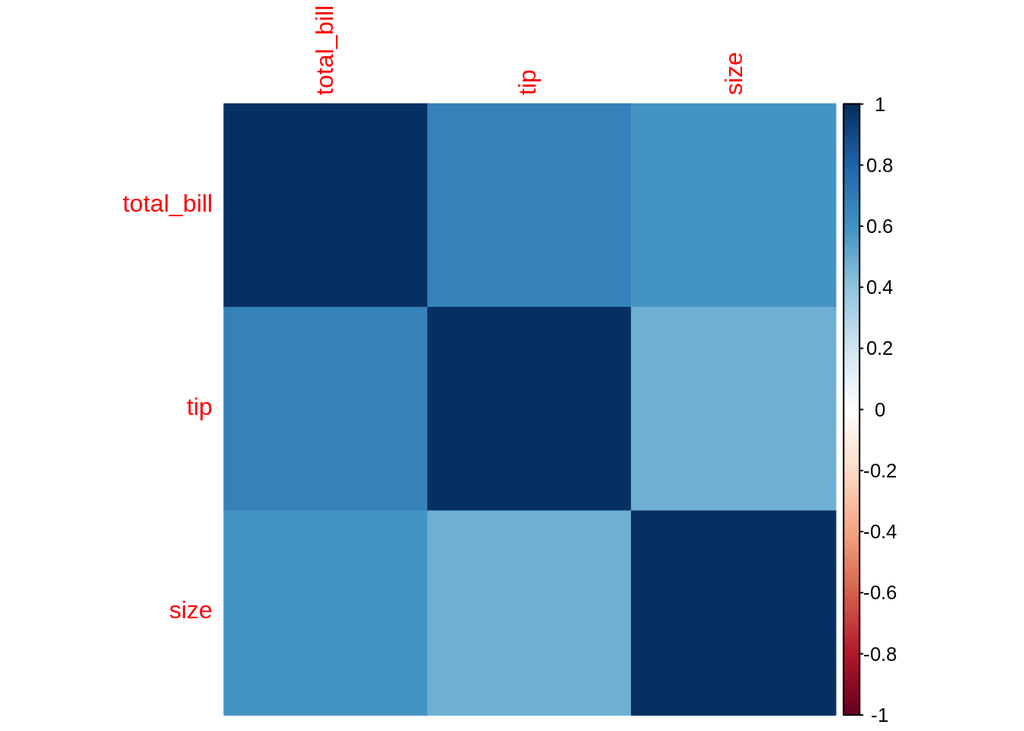

```r
# Correlation check
corr <- cor(tips_num)
corrplot(corr, method = "color")
```

## 6.2 Checking for Influence Points

```r
inflm.model <-  influence.measures(model)
which(apply(inflm.model$is.inf, 1, any))
```

```
##  24  89  92  93  95  96  99 100 101 103 126 144 171 173 182 184 188 198 213 215
##  24  89  92  93  95  96  99 100 101 103 126 144 171 173 182 184 188 198 213 215
## 238
## 238
```

```r
# Which observations 'are' influential
sum_inflm <- summary(inflm.model)
```

```
## Potentially influential observations of
##   lm(formula = tip ~ ., data = new_tips) :
##
##     dfb.1_ dfb.ttl_ dfb.sex dfb.smkr dfb.day dfb.time dfb.size dffit   cov.r
## 24   0.08   0.27     0.08   -0.19    -0.15   -0.12     0.02     0.45    0.89_*
## 89  -0.07   0.24     0.16   -0.17    -0.01    0.22    -0.22     0.45    0.89_*
## 92   0.07   0.02     0.02   -0.05    -0.09   -0.07    -0.02     0.10    1.11_*
## 93  -0.10   0.06     0.04   -0.02     0.10    0.10    -0.04    -0.15    1.10_*
## 95   0.01   0.00     0.00   -0.01    -0.01   -0.01     0.00     0.01    1.11_*
## 96  -0.04  -0.03    -0.02   -0.01     0.09    0.06    -0.02    -0.11    1.12_*
## 99   0.01   0.00     0.00    0.00    -0.01   -0.01     0.00     0.02    1.09_*
## 100 -0.16   0.03    -0.05    0.08     0.18    0.14    -0.01    -0.20    1.09_*
## 101  0.08  -0.03    -0.03    0.02    -0.09   -0.08     0.02     0.11    1.09_*
## 103 -0.05  -0.58     0.35   -0.13     0.00    0.06     0.25    -0.74_*  0.85_*
## 126  0.02   0.02     0.03    0.00     0.02   -0.02    -0.10    -0.13    1.12_*
```

[output cut: 32 more lines]

```r
n = dim(sum_inflm)[1]
n
```

```
## [1] 21
```

```r
k = dim(sum_inflm)[2]
k
```

```
## [1] 11
```

```r
# Limits of DFBETAS and DFFITS
DFbetalim = 2 / sqrt(n)
DFbetalim
```

```
## [1] 0.4364358
```

```r
DFfitslim = 2 * sqrt(k/n)
DFfitslim
```

```
## [1] 1.447494
```

```r
list_inflm = list()
```

```r
for (i in 1 : n) {
  # Checking Cook's D-statistic
  if (sum_inflm[i, "cook.d"] > 1) {
    append(list_inflm, c(i))
  }
  # Checking DFBETAS
  for (j in 1 : (k - 4)) {
    if (sum_inflm[i, j] > DFbetalim) {
      append(list_inflm, c(i))
    }
  }
  # Checking DFFITS
  if (sum_inflm[i, "dffit"] > DFfitslim) {
    append(list_inflm, c(i))
  }
}

# Get the list of influential points
list_inflm <- unique(list_inflm)
print(length(list_inflm))
```

```
## [1] 0
```

## 6.3 Multicolinearity Check (for numeric only)

```r
model_num <- lm(tip ~ ., data = tips_num)
summary(model_num)
```

```
##
## Call:
## lm(formula = tip ~ ., data = tips_num)
##
## Residuals:
##     Min      1Q  Median      3Q     Max
## -2.9279 -0.5547 -0.0852  0.5095  4.0425
##
## Coefficients:
##             Estimate Std. Error t value Pr(>|t|)
## (Intercept) 0.668945   0.193609   3.455  0.00065 ***
## total_bill  0.092713   0.009115  10.172  < 2e-16 ***
## size        0.192598   0.085315   2.258  0.02487 *
## ---
## Signif. codes:  0 '***' 0.001 '**' 0.01 '*' 0.05 '.' 0.1 ' ' 1
##
## Residual standard error: 1.014 on 241 degrees of freedom
## Multiple R-squared:  0.4679, Adjusted R-squared:  0.4635
## F-statistic: 105.9 on 2 and 241 DF,  p-value: < 2.2e-16
```

```r
# Variation Inflation Factor
vif(model_num)
```

```
## total_bill       size
##   1.557586   1.557586
```

Observation : No such multicolinearity as VIF < 4 for all variables

## 6.4 Check the normality of the residuals

```r
# Calculate standardised residuals
res <- resid(model)
mean(res)
```

```
## [1] 9.708797e-17
```

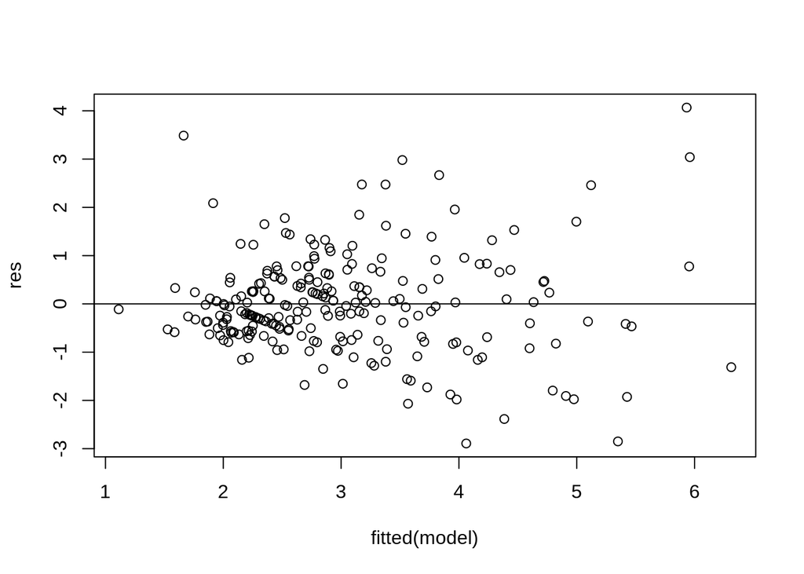

```r
plot(fitted(model), res)
# Add a horizontal line at 0
abline(0, 0)
```

The residuals vs the fitted values seems to form a funnel, failing the assumption of Homoskadasticity

```r
df_res <- as.data.frame(res)
```

### 6.4.1 Distribution Curves

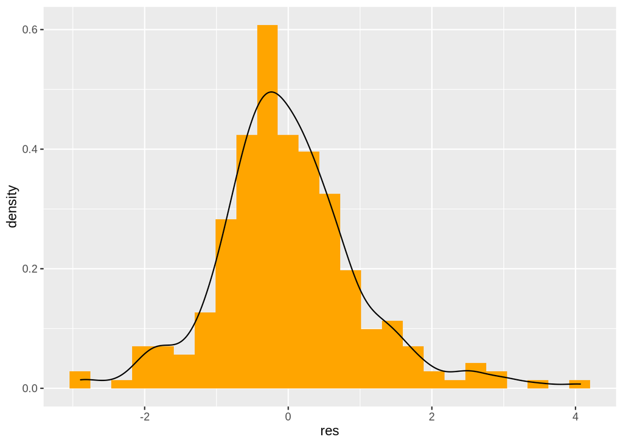

```r
ggplot(data = df_res, aes(x = res)) +
  geom_histogram(bins = 25, aes(y =..density..), fill = "orange") +
  geom_density()
```

The residuals can be said to be approximated to normal distribution, but still, we will try doing other tests and proceed with necessary measures.

### 6.4.2 QQ-Plot

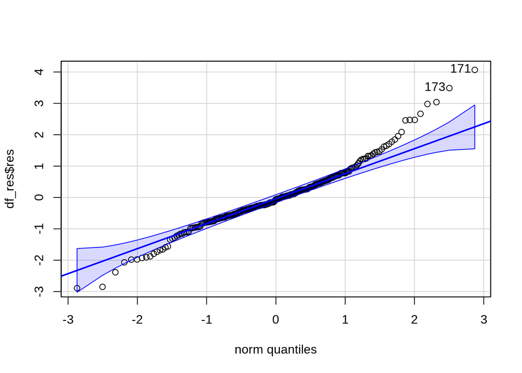

```
## [1] 171 173
```

```r
qqPlot(df_res$res)
```

The data doesn’t seems to fit into a straight line. Hence, the residuals cannot be assumed to be normal.

### 6.4.3 Shapiro-Wilks Test

```r
# It is based on the correlation between the data and the corresponding normal scores.
# H0 : Part of Normal distribution
# H1 : Not part of normal distribution
shapiro.test(df_res$res)
```

```
##
##  Shapiro-Wilk normality test
##
## data:  df_res$res
## W = 0.96463, p-value = 9.795e-06
```

The p-value of the SWT is less than 0.05, therefore, we reject it as a normal distribution.

From Shapiro-Wilk test, we get that the distribution of the residuals are not normal.  
We should be checking the existence of outliers in both dependent and independent variables now.  
But the model without outliers, is poorer than the normal, and therefore this code is given below commented.

```r
# # Outlier Detection
# meltData <- melt(tips_num)
# p <- ggplot(meltData, aes(factor(variable), value))
# p + geom_boxplot() + facet_wrap(~variable, scale="free")
#
# # Removing outliers by using IQR
# # tip
# Q1 <- quantile(new_tips$tip, .25)
# Q3 <- quantile(new_tips$tip, .75)
# IQR <- IQR(new_tips$tip)
# new_tips <- subset(new_tips, new_tips$tip > (Q1 - 1.5*IQR) & new_tips$tip < (Q3 + 1.5*IQR))
# dim(new_tips)
# # total_bill
# Q1 <- quantile(new_tips$total_bill, .25)
# Q3 <- quantile(new_tips$total_bill, .75)
# IQR <- IQR(new_tips$total_bill)
# new_tips <- subset(new_tips, new_tips$total_bill > (Q1 - 1.5*IQR) & new_tips$total_bill < (Q3 + 1.5*IQR))
# dim(new_tips)
# # size
# Q1 <- quantile(new_tips$size, .25)
# Q3 <- quantile(new_tips$size, .75)
# IQR <- IQR(new_tips$size)
# new_tips <- subset(new_tips, new_tips$size > (Q1 - 1.5*IQR) & new_tips$size < (Q3 + 1.5*IQR))
# dim(new_tips)
# # By this technique, we have managed to reduce the observations from 244 to 221.
#
# # Building a Generalised Model
# model2 <- lm(tip ~ ., data = new_tips)
# summary(model2)
#
# ors <- rstandard(model2)
# df_res <- as.data.frame(ors)

# Now, we would have to plot the distribution curve and the QQ plot to verify
# if our data has become Normal.
# ggplot(data = df_res, aes(ors)) +
#   geom_histogram(bins= 25, aes(y =..density..), fill = "orange") +
#   geom_density()
# # The residuals can be said to be approximated to normal distribution,
# # but we will confirm it with QQ-plot and SWT.
#
# # QQ-Plot
# qqPlot(df_res$ors)
# # The data seems to fit into a straight line still. Hence, further treatment is required.
#
# # Shapiro-Wilks Test
# shapiro.test(df_res$ors)
# # W = 0.98182, p-value = 0.006065
# # The p-value of the SWT is less than 0.05, therefore, we reject it, yet again, as a normal distribution.
```

### 6.4.4 Box Cox Transformation

```r
bc <- boxcox(model)
```

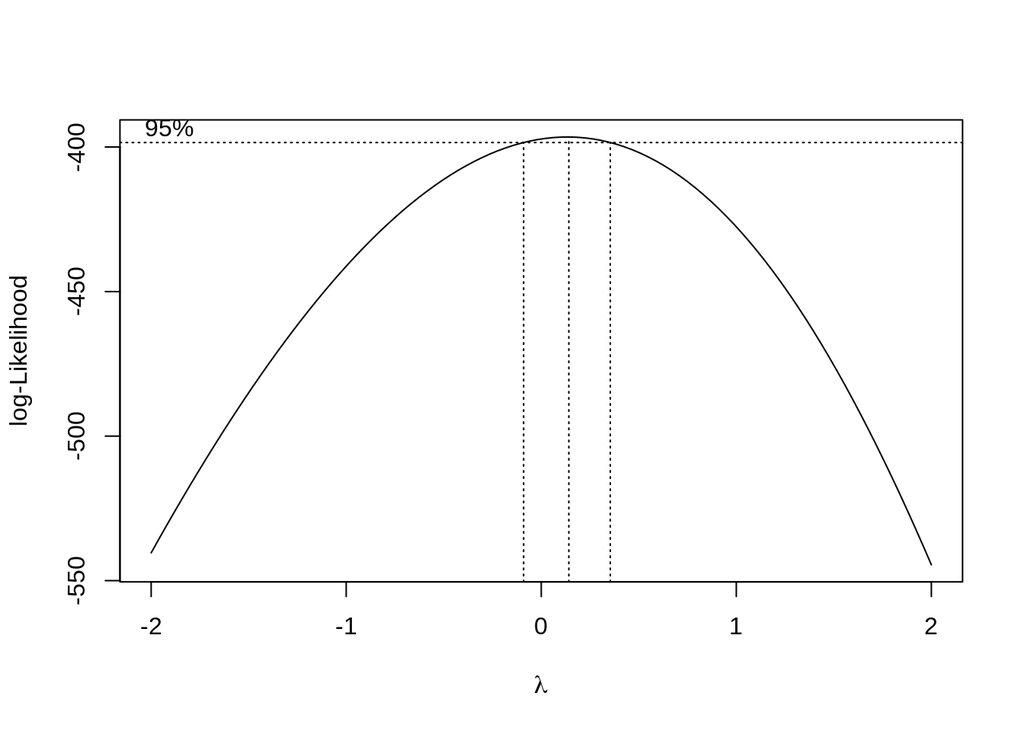

```r
(lambda <- bc$x[which.max(bc$y)])
```

```
## [1] 0.1414141
```

```r
new_model <- lm((tip^lambda - 1)/lambda ~ ., data = new_tips)
summary(new_model)
```

```
##
## Call:
## lm(formula = (tip^lambda - 1)/lambda ~ ., data = new_tips)
##
## Residuals:
##     Min      1Q  Median      3Q     Max
## -1.3006 -0.2492  0.0194  0.2500  1.2116
##
## Coefficients:
##              Estimate Std. Error t value Pr(>|t|)
## (Intercept)  0.247647   0.238786   1.037   0.3007
## total_bill   0.032979   0.003546   9.300   <2e-16 ***
## sex         -0.019213   0.052517  -0.366   0.7148
## smoker      -0.021345   0.053515  -0.399   0.6904
## day          0.017184   0.037372   0.460   0.6461
## time         0.018880   0.075836   0.249   0.8036
## size         0.069836   0.033176   2.105   0.0363 *
## ---
## Signif. codes:  0 '***' 0.001 '**' 0.01 '*' 0.05 '.' 0.1 ' ' 1
##
## Residual standard error: 0.3802 on 237 degrees of freedom
## Multiple R-squared:  0.4475, Adjusted R-squared:  0.4335
## F-statistic: 31.99 on 6 and 237 DF,  p-value: < 2.2e-16
```

```r
res <- resid(new_model)
mean(res)
```

```
## [1] 3.323702e-18
```

The assumption of the zero mean holds. Mean of residuals = 3.323702e-18 ~ 0

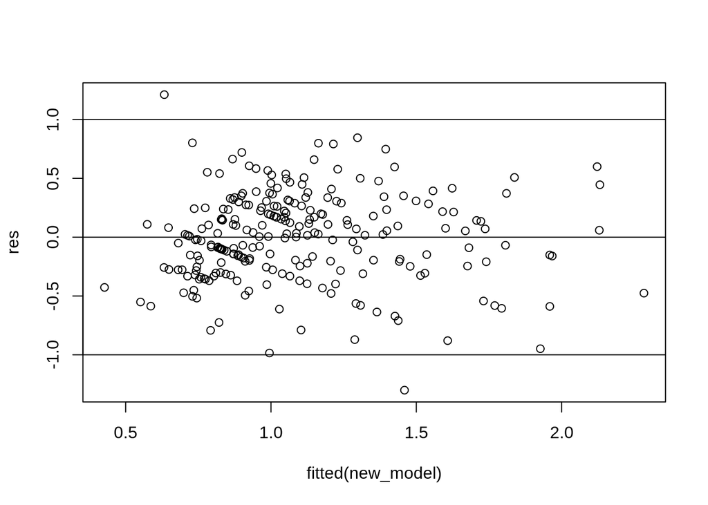

```r
plot(fitted(new_model), res)
# Add a horizontal line at 0
abline(0, 0)
abline(1, 0)
abline(-1, 0)
```

The residuals vs the fitted values seems to form a horizontal band around 0, validating the assumption of Homoskadasticity.

### 6.4.5 Reaffirming the normality of the residuals after boxcox transformation

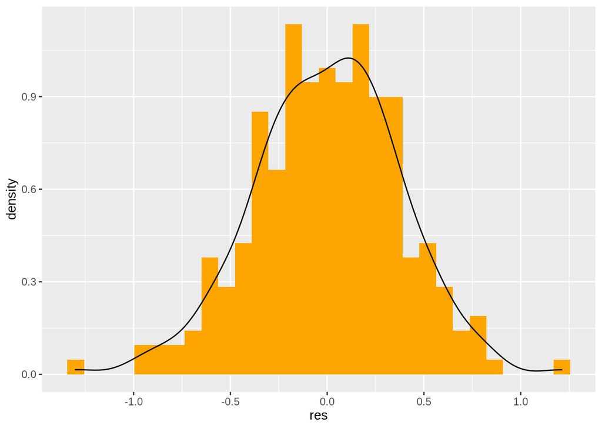

```r
df_res <- as.data.frame(res)

# Distribution Curves
ggplot(data = df_res, aes(x = res)) +
  geom_histogram(aes(y =..density..), fill = "orange") +
  geom_density()
```

The residuals can be said to be approximated to normal distribution, but still, we will try doing other tests and proceed with necessary measures.

```r
# Shapiro-Wilks Test
shapiro.test(df_res$res)
```

```
##
##  Shapiro-Wilk normality test
##
## data:  df_res$res
## W = 0.99617, p-value = 0.8144
```

The residuals are normally distributed as p value greater than 0.05

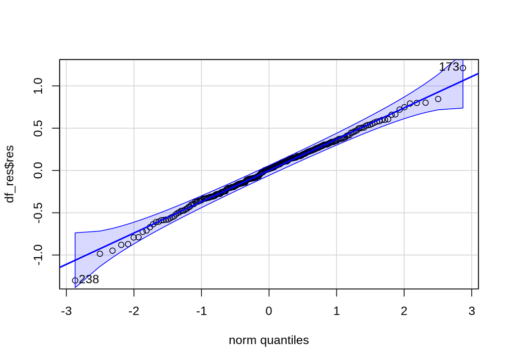

```
## [1] 238 173
```

```r
# QQ-Plot
qqPlot(df_res$res)
```

The data seems to fit into a straight line. Hence, the residuals can be assumed to be normal.  
There are two observations that seems to be the outliers and hence we would remove those.

```r
dim(new_tips)
```

```
## [1] 244   7
```

```r
new_tips <- new_tips[-c(173, 238), ]
dim(new_tips)
```

```
## [1] 242   7
```

```r
# Transforming Y variable using boxcox
for(i in 1 : dim(new_tips)[1])
  new_tips[i, "tip"] = ((new_tips[i, "tip"]^lambda - 1) / lambda)
head(new_tips)
```

```
##   total_bill         tip sex smoker day time size
## 1      16.99 0.009957335   1      1   4    1    2
## 2      10.34 0.525421496   2      1   4    1    3
## 3      21.01 1.370585550   2      1   4    1    3
## 4      23.68 1.304215016   2      1   4    1    2
## 5      24.59 1.407609030   1      1   4    1    4
## 6      25.29 1.732607893   2      1   4    1    4
```

# 7 Feature Selection

```r
# Forward Selection
FSR = regsubsets(tip ~ ., data = new_tips, method = "forward")
summary(FSR)
```

```
## Subset selection object
## Call: regsubsets.formula(tip ~ ., data = new_tips, method = "forward")
## 6 Variables  (and intercept)
##            Forced in Forced out
## total_bill     FALSE      FALSE
## sex            FALSE      FALSE
## smoker         FALSE      FALSE
## day            FALSE      FALSE
## time           FALSE      FALSE
## size           FALSE      FALSE
## 1 subsets of each size up to 6
## Selection Algorithm: forward
##          total_bill sex smoker day time size
## 1  ( 1 ) "*"        " " " "    " " " "  " "
## 2  ( 1 ) "*"        " " " "    " " " "  "*"
## 3  ( 1 ) "*"        " " "*"    " " " "  "*"
## 4  ( 1 ) "*"        "*" "*"    " " " "  "*"
## 5  ( 1 ) "*"        "*" "*"    "*" " "  "*"
## 6  ( 1 ) "*"        "*" "*"    "*" "*"  "*"
```

```r
Modelsummary.1 = cbind(summary(FSR)$which, R2=summary(FSR)$rsq, SSres=summary(FSR)$rss,
                     AdjR2=summary(FSR)$adjr2, Cp=summary(FSR)$cp, BIC=summary(FSR)$bic)
Modelsummary.1
```

```
##   (Intercept) total_bill sex smoker day time size        R2    SSres     AdjR2
## 1           1          1   0      0   0    0    0 0.4784346 31.58450 0.4762615
## 2           1          1   0      0   0    0    1 0.4867972 31.07809 0.4825026
## 3           1          1   0      1   0    0    1 0.4878791 31.01257 0.4814238
## 4           1          1   1      1   0    0    1 0.4882515 30.99002 0.4796144
## 5           1          1   1      1   1    0    1 0.4882738 30.98867 0.4774322
## 6           1          1   1      1   1    1    1 0.4883000 30.98708 0.4752353
##           Cp       BIC
## 1  1.5306806 -146.5449
## 2 -0.3098627 -144.9676
## 3  1.1932989 -139.9893
## 4  3.0222614 -134.6764
## 5  5.0119946 -129.1981
## 6  7.0000000 -123.7215
```

```r
# Backward elimination
BER = regsubsets(tip ~ ., data = new_tips, method = "backward")
Modelsummary.2 = cbind(summary(BER)$which, R2=summary(BER)$rsq, SSres=summary(BER)$rss,
                       AdjR2=summary(BER)$adjr2, Cp=summary(BER)$cp, BIC=summary(BER)$bic)
Modelsummary.2
```

```
##   (Intercept) total_bill sex smoker day time size        R2    SSres     AdjR2
## 1           1          1   0      0   0    0    0 0.4784346 31.58450 0.4762615
## 2           1          1   0      0   0    0    1 0.4867972 31.07809 0.4825026
## 3           1          1   0      1   0    0    1 0.4878791 31.01257 0.4814238
## 4           1          1   1      1   0    0    1 0.4882515 30.99002 0.4796144
## 5           1          1   1      1   1    0    1 0.4882738 30.98867 0.4774322
## 6           1          1   1      1   1    1    1 0.4883000 30.98708 0.4752353
##           Cp       BIC
## 1  1.5306806 -146.5449
## 2 -0.3098627 -144.9676
## 3  1.1932989 -139.9893
## 4  3.0222614 -134.6764
## 5  5.0119946 -129.1981
## 6  7.0000000 -123.7215
```

```r
# Stepwise Regression
SWR = regsubsets(tip ~ ., data = new_tips, method = "seqrep")
Modelsummary.3 = cbind(summary(SWR)$which, R2=summary(SWR)$rsq, SSres=summary(SWR)$rss,
                       AdjR2=summary(SWR)$adjr2, Cp=summary(SWR)$cp, BIC=summary(SWR)$bic)
Modelsummary.3
```

```
##   (Intercept) total_bill sex smoker day time size        R2    SSres     AdjR2
## 1           1          1   0      0   0    0    0 0.4784346 31.58450 0.4762615
## 2           1          1   0      0   0    0    1 0.4867972 31.07809 0.4825026
## 3           1          1   0      1   0    0    1 0.4878791 31.01257 0.4814238
## 4           1          1   1      1   1    0    0 0.4817572 31.38330 0.4730105
## 5           1          1   1      1   1    1    0 0.4818968 31.37484 0.4709201
## 6           1          1   1      1   1    1    1 0.4883000 30.98708 0.4752353
##           Cp       BIC
## 1  1.5306806 -146.5449
## 2 -0.3098627 -144.9676
## 3  1.1932989 -139.9893
## 4  6.0048003 -131.6247
## 5  7.9406606 -126.2009
## 6  7.0000000 -123.7215
```

Recommendation : total_bill, size from all the 3 methods

# 8 Final Model

## 8.1 Training the mode;

```r
set.seed(108)

# Splitting the dataset into train and test 8:2
trainPartitionRows <- createDataPartition(new_tips$tip, p = .80, list = FALSE)
nrow(new_tips)
```

```
## [1] 242
```

```r
nrow(trainPartitionRows)
```

```
## [1] 195
```

```r
head(trainPartitionRows)
```

```
##      Resample1
## [1,]         1
## [2,]         2
## [3,]         3
## [4,]         4
## [5,]         6
## [6,]         7
```

```r
trainDataset <- new_tips[ trainPartitionRows, ]
testDataset  <- new_tips[-trainPartitionRows, ]
head(trainDataset)
```

```
##   total_bill         tip sex smoker day time size
## 1      16.99 0.009957335   1      1   4    1    2
## 2      10.34 0.525421496   2      1   4    1    3
## 3      21.01 1.370585550   2      1   4    1    3
## 4      23.68 1.304215016   2      1   4    1    2
## 6      25.29 1.732607893   2      1   4    1    4
## 7       8.77 0.728256317   2      1   4    1    2
```

```r
head(testDataset)
```

```
##    total_bill       tip sex smoker day time size
## 5       24.59 1.4076090   1      1   4    1    4
## 10      14.78 1.2752867   2      1   4    1    2
## 12      35.26 1.8073127   1      1   4    1    4
## 13      15.42 0.4657732   2      1   4    1    2
## 16      21.58 1.5069696   2      1   4    1    2
## 17      10.33 0.5318765   1      1   4    1    3
```

```r
# Repeated Cross Validation
ctrl <- trainControl(
  method = "repeatedcv",
  number = 10,
  repeats = 10
)
tips_model <- train(tip ~ total_bill + size,
                    data = new_tips,
                    method = "lm",
                    trControl = ctrl,
)
tips_model
```

```
## Linear Regression
##
## 242 samples
##   2 predictor
##
## No pre-processing
## Resampling: Cross-Validated (10 fold, repeated 10 times)
## Summary of sample sizes: 218, 219, 217, 218, 217, 218, ...
## Resampling results:
##
##   RMSE       Rsquared   MAE
##   0.3598576  0.4966135  0.2927397
##
## Tuning parameter 'intercept' was held constant at a value of TRUE
```

Train RMSE = 0.3598576  
R-squared = 0.4966135  
MAE = 0.2927397

```r
summary(tips_model)
```

```
##
## Call:
## lm(formula = .outcome ~ ., data = dat)
##
## Residuals:
##     Min      1Q  Median      3Q     Max
## -1.0035 -0.2415  0.0214  0.2485  0.8444
##
## Coefficients:
##             Estimate Std. Error t value Pr(>|t|)
## (Intercept)  0.24166    0.06911   3.497 0.000561 ***
## total_bill   0.03520    0.00329  10.698  < 2e-16 ***
## size         0.06034    0.03058   1.973 0.049597 *
## ---
## Signif. codes:  0 '***' 0.001 '**' 0.01 '*' 0.05 '.' 0.1 ' ' 1
##
## Residual standard error: 0.3606 on 239 degrees of freedom
## Multiple R-squared:  0.4868, Adjusted R-squared:  0.4825
## F-statistic: 113.4 on 2 and 239 DF,  p-value: < 2.2e-16
```

## 8.2 Saving model to an RDS file

```r
# Save a single object to a file
saveRDS(tips_model, "./Model_tips.rds")
```

## 8.3 Running the model on test data

```r
str(testDataset)
```

```
## 'data.frame':    47 obs. of  7 variables:
##  $ total_bill: num  24.6 14.8 35.3 15.4 21.6 ...
##  $ tip       : num  1.408 1.275 1.807 0.466 1.507 ...
##  $ sex       : int  1 2 1 2 2 1 2 2 2 1 ...
##  $ smoker    : int  1 1 1 1 1 1 1 1 1 1 ...
##  $ day       : int  4 4 4 4 4 4 3 3 3 3 ...
##  $ time      : int  1 1 1 1 1 1 1 1 1 1 ...
##  $ size      : int  4 2 4 2 2 3 4 2 2 2 ...
```

```r
test <- testDataset %>% dplyr::select(-c(tip))
pred <- predict(tips_model, test)

vals <- data.frame(predicted = pred, actual = testDataset$tip)

test_RMSE <- sqrt(mean((vals$predicted - vals$actual)^2))
test_RMSE
```

```
## [1] 0.3297749
```

# 9 Remarks

1. The model has pretty low R-squared but the Test RMSE is still less than the Train RMSE.
2. Using One-Hot Encoding for the categorical variables yielded even less R-squared value, hence, the choice of Ordinal Encoding has been taken up, even though there was no such ordering possible among the categories.
3. Outliers were removed by using the IQR tactics, but that too yielded a much poorer model.
4. Residuals were used instead of standardised or studentized residuals.

# 10 End of Project